# My Portfolio for Computational Musicology 2025

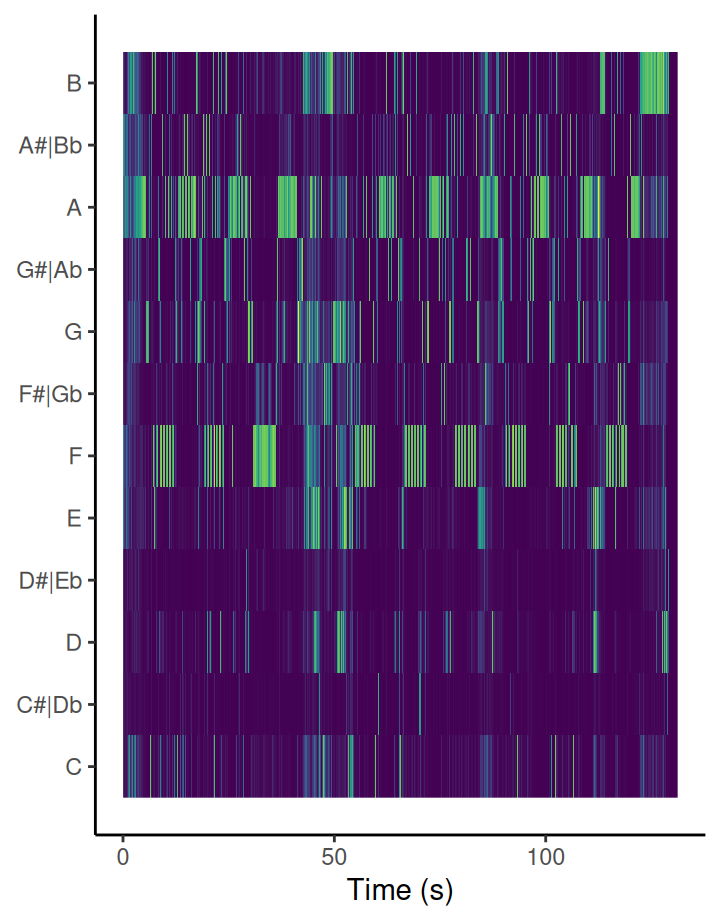

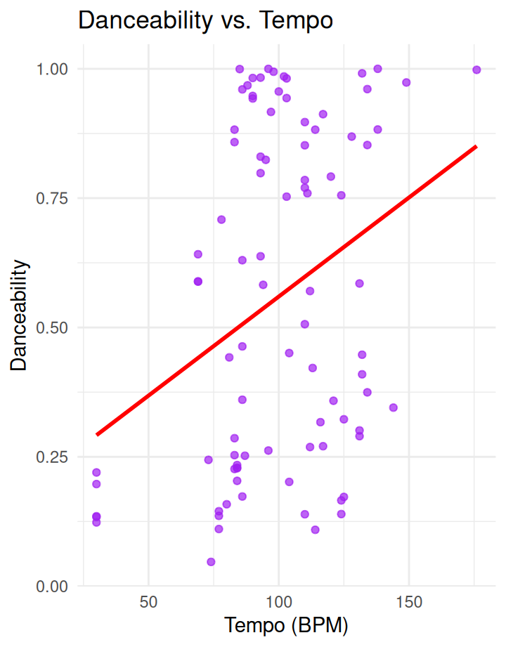

## Welcome to my dashboard!

This dashboard includes insights into music analysis, visualizations, and key musical features.

### Tab 1: Tempi and Music Features

### Insights

The first song has a dark, atmospheric 80s-inspired synthwave beat with smooth R&B elements, like The Weeknd, moody, energetic, downtempo, made with Udio.ai.

The second song is dembow, reggaeton, cumbia, afro-latin fusion, rap, latin trap. It’s like a summer song that will bring you back to the summer, made with Suno.ai.

#### Song Analysis

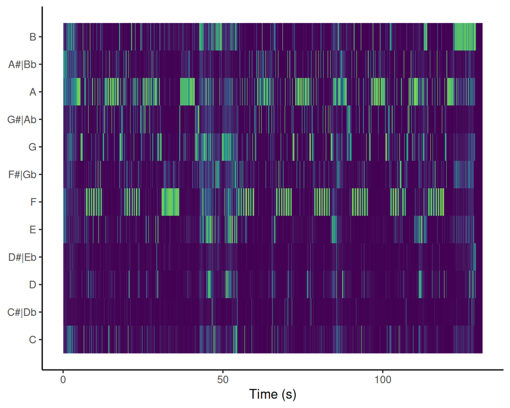

### Tab 2: Discovery and Insights into Arousal

### More Insights

The dataset contains several features related to danceability, tempo, and arousal. This section focuses on the relationships between these features.

#### Danceability and Tempo

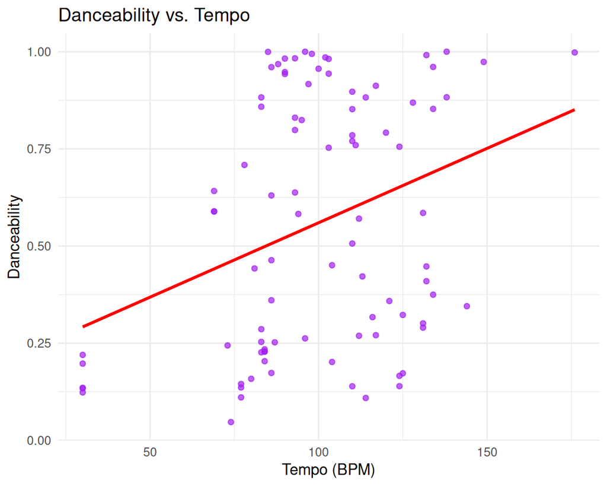

### Interactive Plots

#### Chart 1

[interactive chart not shown]

### Final Insights

Each tab in the `flexdashboard` now has a specific sidebar that provides context or insight relevant to the content displayed within the tab. The sidebar content will change dynamically when you switch between tabs.

This approach leverages `flexdashboard`’s ability to place sidebars under each individual section (`Column`). By customizing the sidebar content in each column, we ensure that the sidebar updates based on the active tab.